# regularizacion_nba

Hugo César Octavio del Sueldo

11/9/2020

## Prediccion en el Data Set NBA

El data set `nba` muestra informacion sobre los salarios y los rendimientos de los jugadores de la NBA

### Exploratory data analysis of the data set

- Player: Nombre del jugador.
- Salary: Salario en dolares.
- NBA_Country: NAcionalidad del jugador.
- NBA_DraftNumber: Posición del draft.
- Age: Edad del jugador.
- Tm: Abreviatura del nombre.
- G: Partidos jugados
- MP: Minutos jugados.
- PER: Índice de eficiencia del jugador. El promedio de la liga es 15.
- TS = Porcentaje de tiro real. Tiene en cuenta los tiros de 2 puntos, los triples y los tiros libres.
- TMP: Minutos jugados por el equipo.
- 3PAr: Porcentaje de triples.
- FTr: Porcentaje de tiros libres.
- ORB%Offensive Rebound Percentage (ORB%): Porcentaje de rebotes ofensivos.
- DRB%: Porcentaje de rebote defensivo.
- TRB%: Porcentaje de rebote total.
- AST%: Porcentaje de asistencia.
- STL%: Porcentaje de robo.
- BLK%: Porcentaje de tapones.
- TOV%: Porcentaje de robo de balón antes de que el equipo contrario tire.
- USG%: Porcentaje de jugadas que estuvo involucrado un jugador, siempre que la jugada termine en uno de los tres resultados reales: intento de gol de campo, intento de tiro libre o pérdida.
- OWS: Acciones de victoria ofensivas.
- DWS: Acciones de victorias defensivas.
- WS: Un número estimado de victorias a las que un jugador ha contribuido.
- WS/48: WS por 48 minutos.
- BPM: Calcula el más/menos de un jugador respecto al rendimiento del equipo por cada 100 posesiones ofensivas.
- DBPM: Calcula el más/menos de un jugador respecto al rendimiento del equipo por cada 100 posesiones defensivas.
- BPM: Calcula el más/menos de un jugador respecto al rendimiento del equipo por cada 100 posesiones.
- VORP: Valor sobre jugador de reemplazo.

#### Cambio los nombres de algunas columnas

Algunas columnas tienen nombres con los simbolos del %, comienzan con numeros o / que nos afectan a la hora de hacer calculos. Por lo tanto, vamos a modificarlas para poder trabajar correctamente.

```r
nba %<>% clean_names()
colnames(nba)
```

```
##  [1] "player"           "salary"           "nba_country"      "nba_draft_number"
##  [5] "age"              "tm"               "g"                "mp"
##  [9] "per"              "ts_percent"       "x3p_ar"           "f_tr"
## [13] "orb_percent"      "drb_percent"      "trb_percent"      "ast_percent"
## [17] "stl_percent"      "blk_percent"      "tov_percent"      "usg_percent"
## [21] "ows"              "dws"              "ws"               "ws_48"
## [25] "obpm"             "dbpm"             "bpm"              "vorp"
```

### Summarize data

```r
skim(nba)
```

Data summary

| Name | nba |
| --- | --- |
| Number of rows | 485 |
| Number of columns | 28 |
| _______________________ |  |
| Column type frequency: |  |
| character | 3 |
| numeric | 25 |
| ________________________ |  |
| Group variables | None |

**Variable type: character**

| skim_variable | n_missing | complete_rate | min | max | empty | n_unique | whitespace |
| --- | --- | --- | --- | --- | --- | --- | --- |
| player | 0 | 1 | 7 | 24 | 0 | 483 | 0 |
| nba_country | 0 | 1 | 3 | 16 | 0 | 44 | 0 |
| tm | 0 | 1 | 3 | 3 | 0 | 31 | 0 |

**Variable type: numeric**

| skim_variable | n_missing | complete_rate | mean | sd | p0 | p25 | p50 | p75 | p100 | hist |
| --- | --- | --- | --- | --- | --- | --- | --- | --- | --- | --- |
| salary | 0 | 1 | 6636507.50 | 7392601.91 | 46080.00 | 1471382.00 | 3202217.00 | 1.000e+07 | 34682550.00 | ▇▂▁▁▁ |
| nba_draft_number | 0 | 1 | 29.45 | 21.13 | 1.00 | 11.00 | 25.00 | 4.700e+01 | 62.00 | ▇▆▃▃▆ |
| age | 0 | 1 | 26.26 | 4.27 | 19.00 | 23.00 | 26.00 | 2.900e+01 | 41.00 | ▇▇▆▂▁ |
| g | 0 | 1 | 50.17 | 24.87 | 1.00 | 29.00 | 59.00 | 7.100e+01 | 79.00 | ▃▂▂▃▇ |
| mp | 0 | 1 | 1154.14 | 811.36 | 1.00 | 381.00 | 1134.00 | 1.819e+03 | 2898.00 | ▇▅▆▅▂ |
| per | 0 | 1 | 13.26 | 8.77 | -41.10 | 9.80 | 13.20 | 1.650e+01 | 134.10 | ▁▇▁▁▁ |
| ts_percent | 2 | 1 | 0.54 | 0.11 | 0.00 | 0.51 | 0.54 | 5.800e-01 | 1.50 | ▁▇▂▁▁ |
| x3p_ar | 2 | 1 | 0.34 | 0.23 | 0.00 | 0.17 | 0.35 | 4.800e-01 | 1.00 | ▇▇▇▂▁ |
| f_tr | 2 | 1 | 0.26 | 0.29 | 0.00 | 0.16 | 0.23 | 3.200e-01 | 5.33 | ▇▁▁▁▁ |
| orb_percent | 0 | 1 | 4.87 | 4.58 | 0.00 | 1.80 | 3.20 | 7.000e+00 | 35.90 | ▇▂▁▁▁ |
| drb_percent | 0 | 1 | 14.95 | 6.85 | 0.00 | 10.20 | 14.00 | 1.880e+01 | 37.60 | ▂▇▅▂▁ |
| trb_percent | 0 | 1 | 9.91 | 4.96 | 0.00 | 6.20 | 8.70 | 1.330e+01 | 26.50 | ▂▇▃▂▁ |
| ast_percent | 0 | 1 | 12.95 | 9.11 | 0.00 | 6.90 | 9.90 | 1.760e+01 | 49.40 | ▇▅▂▁▁ |
| stl_percent | 0 | 1 | 1.53 | 0.99 | 0.00 | 1.00 | 1.50 | 1.900e+00 | 12.50 | ▇▁▁▁▁ |
| blk_percent | 0 | 1 | 1.71 | 1.68 | 0.00 | 0.60 | 1.20 | 2.200e+00 | 13.40 | ▇▂▁▁▁ |
| tov_percent | 2 | 1 | 13.14 | 6.12 | 0.00 | 9.90 | 12.50 | 1.575e+01 | 66.70 | ▇▆▁▁▁ |
| usg_percent | 0 | 1 | 18.90 | 5.94 | 0.00 | 15.00 | 17.90 | 2.220e+01 | 45.10 | ▁▇▆▁▁ |
| ows | 0 | 1 | 1.28 | 1.88 | -2.30 | 0.00 | 0.80 | 2.000e+00 | 11.40 | ▇▇▂▁▁ |
| dws | 0 | 1 | 1.18 | 1.03 | 0.00 | 0.30 | 1.00 | 1.800e+00 | 5.60 | ▇▅▂▁▁ |
| ws | 0 | 1 | 2.46 | 2.67 | -1.20 | 0.30 | 1.80 | 3.600e+00 | 15.00 | ▇▅▁▁▁ |
| ws_48 | 0 | 1 | 0.08 | 0.16 | -1.06 | 0.04 | 0.08 | 1.200e-01 | 2.71 | ▁▇▁▁▁ |
| obpm | 0 | 1 | -1.27 | 5.03 | -36.50 | -2.70 | -1.10 | 4.000e-01 | 68.70 | ▁▇▁▁▁ |
| dbpm | 0 | 1 | -0.49 | 2.39 | -14.30 | -1.70 | -0.40 | 1.000e+00 | 6.80 | ▁▁▃▇▁ |
| bpm | 0 | 1 | -1.76 | 5.66 | -49.20 | -3.60 | -1.30 | 5.000e-01 | 54.40 | ▁▁▇▁▁ |
| vorp | 0 | 1 | 0.60 | 1.25 | -1.30 | -0.10 | 0.10 | 9.000e-01 | 8.60 | ▇▃▁▁▁ |

Hay dos datos repetidos y varios NA

### Data wrangling

Data wrangling is the process of cleaning and unifying complex data sets for analysis, in turn boosting productivity within an organization.

```r
# delete duplicate
# Remove duplicate rows of the dataframe
nba %<>% distinct(player,.keep_all= TRUE)

# delete NA's
nba %<>% drop_na()

# Summarise
skim(nba)
```

Data summary

| Name | nba |
| --- | --- |
| Number of rows | 481 |
| Number of columns | 28 |
| _______________________ |  |
| Column type frequency: |  |
| character | 3 |
| numeric | 25 |
| ________________________ |  |
| Group variables | None |

**Variable type: character**

| skim_variable | n_missing | complete_rate | min | max | empty | n_unique | whitespace |
| --- | --- | --- | --- | --- | --- | --- | --- |
| player | 0 | 1 | 7 | 24 | 0 | 481 | 0 |
| nba_country | 0 | 1 | 3 | 16 | 0 | 44 | 0 |
| tm | 0 | 1 | 3 | 3 | 0 | 31 | 0 |

**Variable type: numeric**

| skim_variable | n_missing | complete_rate | mean | sd | p0 | p25 | p50 | p75 | p100 | hist |
| --- | --- | --- | --- | --- | --- | --- | --- | --- | --- | --- |
| salary | 0 | 1 | 6682859.45 | 7405536.17 | 46080.00 | 1471382.00 | 3290000.00 | 1.00e+07 | 34682550.00 | ▇▂▁▁▁ |
| nba_draft_number | 0 | 1 | 29.29 | 21.10 | 1.00 | 10.00 | 24.00 | 4.70e+01 | 62.00 | ▇▅▃▃▆ |
| age | 0 | 1 | 26.29 | 4.27 | 19.00 | 23.00 | 26.00 | 2.90e+01 | 41.00 | ▇▇▆▂▁ |
| g | 0 | 1 | 50.52 | 24.67 | 1.00 | 30.00 | 59.00 | 7.10e+01 | 79.00 | ▃▂▂▃▇ |
| mp | 0 | 1 | 1163.17 | 808.61 | 1.00 | 391.00 | 1155.00 | 1.83e+03 | 2898.00 | ▇▅▆▅▂ |
| per | 0 | 1 | 13.36 | 8.74 | -41.10 | 9.90 | 13.30 | 1.66e+01 | 134.10 | ▁▇▁▁▁ |
| ts_percent | 0 | 1 | 0.54 | 0.11 | 0.00 | 0.51 | 0.54 | 5.80e-01 | 1.50 | ▁▇▂▁▁ |
| x3p_ar | 0 | 1 | 0.34 | 0.23 | 0.00 | 0.17 | 0.35 | 4.80e-01 | 1.00 | ▇▇▇▂▁ |
| f_tr | 0 | 1 | 0.26 | 0.30 | 0.00 | 0.16 | 0.23 | 3.20e-01 | 5.33 | ▇▁▁▁▁ |
| orb_percent | 0 | 1 | 4.91 | 4.58 | 0.00 | 1.80 | 3.30 | 7.10e+00 | 35.90 | ▇▂▁▁▁ |
| drb_percent | 0 | 1 | 15.03 | 6.80 | 0.00 | 10.30 | 14.00 | 1.88e+01 | 37.60 | ▂▇▅▂▁ |
| trb_percent | 0 | 1 | 9.97 | 4.93 | 0.00 | 6.20 | 8.70 | 1.33e+01 | 26.50 | ▂▇▃▂▁ |
| ast_percent | 0 | 1 | 12.96 | 9.09 | 0.00 | 6.90 | 9.90 | 1.72e+01 | 49.40 | ▇▅▂▁▁ |
| stl_percent | 0 | 1 | 1.54 | 0.99 | 0.00 | 1.00 | 1.50 | 1.90e+00 | 12.50 | ▇▁▁▁▁ |
| blk_percent | 0 | 1 | 1.72 | 1.69 | 0.00 | 0.60 | 1.20 | 2.20e+00 | 13.40 | ▇▂▁▁▁ |
| tov_percent | 0 | 1 | 13.12 | 6.12 | 0.00 | 9.90 | 12.50 | 1.56e+01 | 66.70 | ▇▆▁▁▁ |
| usg_percent | 0 | 1 | 18.94 | 5.81 | 5.70 | 15.00 | 17.90 | 2.22e+01 | 45.10 | ▂▇▃▁▁ |
| ows | 0 | 1 | 1.29 | 1.88 | -2.30 | 0.00 | 0.80 | 2.00e+00 | 11.40 | ▇▇▂▁▁ |
| dws | 0 | 1 | 1.19 | 1.03 | 0.00 | 0.30 | 1.00 | 1.80e+00 | 5.60 | ▇▅▂▁▁ |
| ws | 0 | 1 | 2.48 | 2.67 | -1.20 | 0.40 | 1.90 | 3.60e+00 | 15.00 | ▇▅▁▁▁ |
| ws_48 | 0 | 1 | 0.08 | 0.16 | -1.06 | 0.04 | 0.08 | 1.20e-01 | 2.71 | ▁▇▁▁▁ |
| obpm | 0 | 1 | -1.22 | 5.02 | -36.50 | -2.60 | -1.00 | 4.00e-01 | 68.70 | ▁▇▁▁▁ |
| dbpm | 0 | 1 | -0.48 | 2.39 | -14.30 | -1.60 | -0.40 | 1.00e+00 | 6.80 | ▁▁▂▇▁ |
| bpm | 0 | 1 | -1.70 | 5.64 | -49.20 | -3.50 | -1.20 | 6.00e-01 | 54.40 | ▁▁▇▁▁ |
| vorp | 0 | 1 | 0.60 | 1.25 | -1.30 | -0.10 | 0.10 | 9.00e-01 | 8.60 | ▇▃▁▁▁ |

#### Ahora que tenemos limpio el data set vamos a utilizar Cross-Validation con los metodos Ridge, Lasso y Elastic Net para tomar el mejor modelo y luego haremos prediccion

### Leave-One-Out Cross-Validation

#### Antes de comenzar con los metodos de regularizacion, probamos el cv error con el modelo estimado por lm

```r
#library(glmnet)
#library (boot)
#library(skimr)
log_data <- nba %>% mutate(salary=log(salary))

vars <- c("player","nba_country","tm")

nba_sincategoricas <- log_data %>% select_at(vars(-vars))
```

```
## Note: Using an external vector in selections is ambiguous.
## ℹ Use `all_of(vars)` instead of `vars` to silence this message.
## ℹ See <https://tidyselect.r-lib.org/reference/faq-external-vector.html>.
```

```r
set.seed(123)
mod1_fit1 = glm(salary ~ .,data = nba_sincategoricas,family = gaussian())
coef(mod1_fit1)
```

```
##      (Intercept) nba_draft_number              age                g
##     10.695694917     -0.022052017      0.099413135     -0.005078876
##               mp              per       ts_percent           x3p_ar
##      0.001050475     -0.183682245      3.172386437     -0.407966952
##             f_tr      orb_percent      drb_percent      trb_percent
##     -0.289433159     -0.076470923     -0.063151465      0.206344313
##      ast_percent      stl_percent      blk_percent      tov_percent
##      0.015719116      0.035993848      0.010690897     -0.021008912
##      usg_percent              ows              dws               ws
##      0.072882785     -0.169824668     -0.416808556      0.175368034
##            ws_48             obpm             dbpm              bpm
##      6.169638628     -0.560164452     -0.503056693      0.582523481
##             vorp
##      0.027421833
```

```r
cv.err =cv.glm(nba_sincategoricas, mod1_fit1)
#delta
# A vector of length two. The first component is the raw cross-validation estimate of prediction error. The second component is the adjusted cross-validation estimate. The adjustment is designed to compensate for the bias introduced by not using leave-one-out cross-validation.
cv.err$delta
```

```
## [1] 1.189333 1.189061
```

## K-Fold Cross-Validation

Supone dividir la muestra en k grupos o folds, de aproximadamente igual tamaño. Cada folds es tratado como un conjunto de validación, de tal forma que se estima el modelo con los datos que no están el fold (los otros k−1 folds) y se predicen en el fold.

```r
#k folds cross validation con todas las variables explicativas menos las categoricas
set.seed(123)
cv.err = cv.glm(nba_sincategoricas, mod1_fit1, K = 10)
cv.err$delta
```

```
## [1] 1.240044 1.222952
```

## REGULARIZACION Y METODOS DE CONTRACCION

### Ridge

```r
#library(rsample)  # data splitting
#library(glmnet)   # implementing regularized regression approaches
#library(dplyr)    # basic data manipulation procedures
#library(ggplot2)  # plotting
```

```r
# Create training (70%) and test (30%) sets for nba data set.
# Use set.seed for reproducibility

set.seed(05112020)
nba_split <- initial_split(nba_sincategoricas, prop = .7, strata = "salary")
nba_train <- training(nba_split)
nba_test  <- testing(nba_split)
```

```r
# Create training and testing feature model matrices and response vectors.
# we use model.matrix(...)[, -1] to discard the intercept
nba_train_x <- model.matrix(salary ~ ., nba_train)[, -1]
nba_train_y <- nba_train$salary

nba_test_x <- model.matrix(salary ~ ., nba_test)[, -1]
nba_test_y <- nba_test$salary

# What is the dimension of of your feature matrix?
dim(nba_train_x)
```

```
## [1] 339  24
```

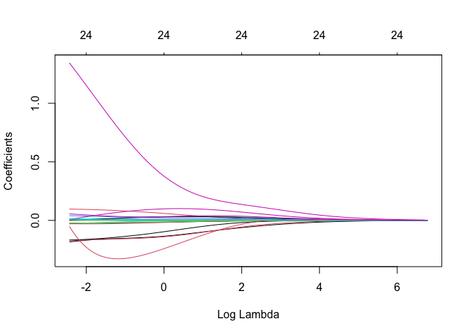

```r
# Apply Ridge regression to nba data
nba_ridge <- glmnet(
  x = nba_train_x,
  y = nba_train_y,
  alpha = 0
)

plot(nba_ridge, xvar = "lambda")
```

```r
# lambdas applied to penalty parameter
nba_ridge$lambda %>% head()
```

```
## [1] 877.9003 799.9100 728.8482 664.0994 605.1026 551.3470
```

### Tuning λ

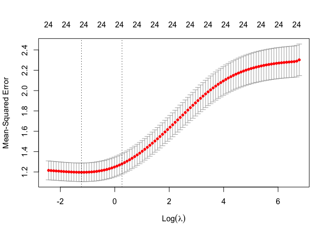

```r
# Apply CV Ridge regression to nba data
nba_ridge_cv <- cv.glmnet(
  x = nba_train_x,
  y = nba_train_y,
  alpha = 0
)

# plot results
plot(nba_ridge_cv)
```

```r
min(nba_ridge_cv$cvm) # minimum MSE
```

```
## [1] 1.196631
```

```r
nba_ridge_cv$lambda.min     # lambda for this min MSE
```

```
## [1] 0.2942373
```

```r
log(nba_ridge_cv$lambda.min) #calculo el logaritmo para verlo visual en el grafico
```

```
## [1] -1.223369
```

```r
nba_ridge_cv$cvm[nba_ridge_cv$lambda == nba_ridge_cv$lambda.1se]  # 1 st.error of min MSE
```

```
## [1] 1.279644
```

```r
nba_ridge_cv$lambda.1se  # lambda for this MSE
```

```
## [1] 1.303654
```

```r
log(nba_ridge_cv$lambda.1se)
```

```
## [1] 0.2651711
```

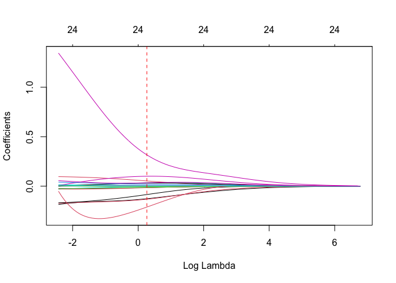

```r
plot(nba_ridge, xvar = "lambda")
abline(v = log(nba_ridge_cv$lambda.1se), col = "red", lty = "dashed")
```

##### Ventajas y Desventajas

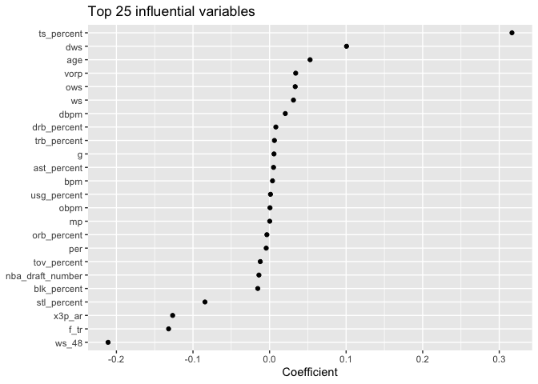

```r
coef(nba_ridge_cv, s = "lambda.1se") %>%
  broom::tidy() %>%
  filter(row != "(Intercept)") %>%
  top_n(25, wt = abs(value)) %>%
  ggplot(aes(value, reorder(row, value))) +
  geom_point() +
  ggtitle("Top 25 influential variables") +
  xlab("Coefficient") +
  ylab(NULL)
```

Observamos aqui la gran desventaja de los modelos ridge que es que no eliminan variables explicativas del modelo.

### Lasso

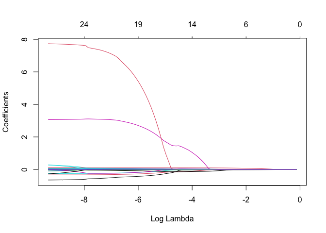

```r
## Apply lasso regression to ames data: alpha=1
nba_lasso <- glmnet(
  x = nba_train_x,
  y = nba_train_y,
  alpha = 1
)

plot(nba_lasso, xvar = "lambda")
```

### Tuning - CV

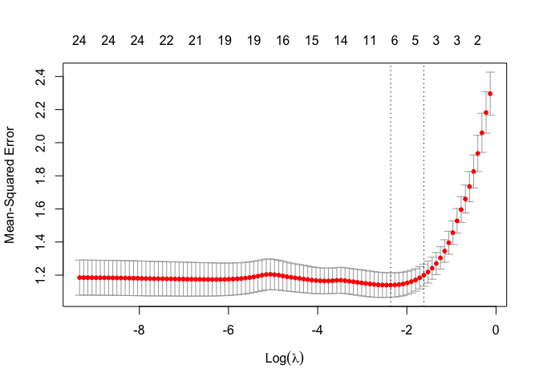

```r
# Apply CV Ridge regression to ames data
nba_lasso_cv <- cv.glmnet(
  x = nba_train_x,
  y = nba_train_y,
  alpha = 1
)
# plot results
plot(nba_lasso_cv)
```

```r
min(nba_lasso_cv$cvm)   # minimum MSE
```

```
## [1] 1.13994
```

```r
nba_lasso_cv$lambda.min     # lambda for this min MSE
```

```
## [1] 0.09413437
```

```r
log(nba_lasso_cv$lambda.min)  #calculo el logaritmo para verlo en el grafico
```

```
## [1] -2.363032
```

```r
nba_lasso_cv$cvm[nba_lasso_cv$lambda == nba_lasso_cv$lambda.1se]  # 1 st.error of min MSE
```

```
## [1] 1.19957
```

```r
nba_lasso_cv$lambda.1se  # lambda for this MSE
```

```
## [1] 0.1981438
```

```r
log(nba_lasso_cv$lambda.1se) #calculo el logaritmo del lambda
```

```
## [1] -1.618762
```

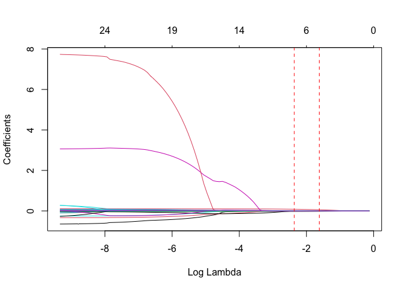

```r
plot(nba_lasso, xvar = "lambda")
abline(v = log(nba_lasso_cv$lambda.min), col = "red", lty = "dashed")
abline(v = log(nba_lasso_cv$lambda.1se), col = "red", lty = "dashed")
```

### Ventajas y Desventajas

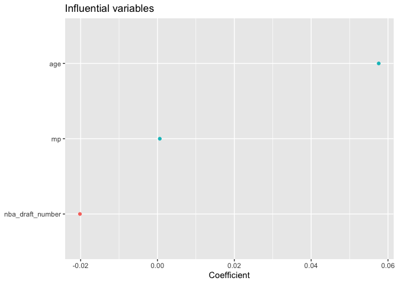

```r
coef(nba_lasso_cv, s = "lambda.1se") %>%
  tidy() %>%
  filter(row != "(Intercept)") %>%
  ggplot(aes(value, reorder(row, value), color = value > 0)) +
  geom_point(show.legend = FALSE) +
  ggtitle("Influential variables") +
  xlab("Coefficient") +
  ylab(NULL)
```

```r
# minimum Ridge MSE
min(nba_ridge_cv$cvm)
```

```
## [1] 1.196631
```

```r
# minimum Lasso MSE
min(nba_lasso_cv$cvm)
```

```
## [1] 1.13994
```

## Elastic Net (Red elástica)

La red elástica es otra penalización que incorpora la selección variable del lazo y la contracción de predictores correlacionados como la regresión de ridge.

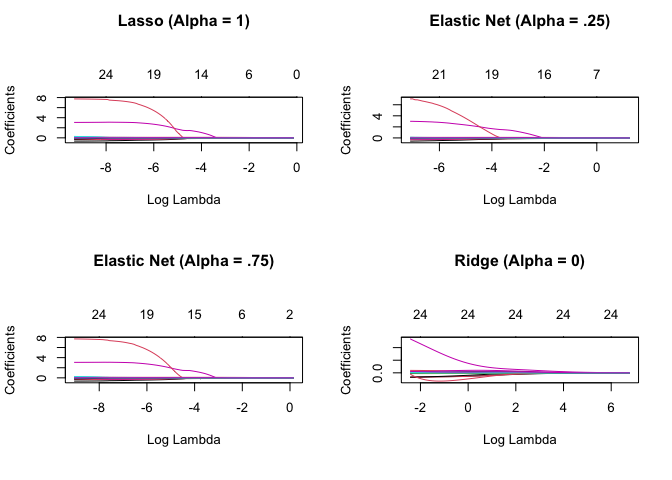

```r
lasso    <- glmnet(nba_train_x, nba_train_y, alpha = 1.0)
elastic1 <- glmnet(nba_train_x, nba_train_y, alpha = 0.25)
elastic2 <- glmnet(nba_train_x, nba_train_y, alpha = 0.75)
ridge    <- glmnet(nba_train_x, nba_train_y, alpha = 0.0)

par(mfrow = c(2, 2), mar = c(6, 4, 6, 2) + 0.1)
plot(lasso, xvar = "lambda", main = "Lasso (Alpha = 1)\n\n\n")
plot(elastic1, xvar = "lambda", main = "Elastic Net (Alpha = .25)\n\n\n")
plot(elastic2, xvar = "lambda", main = "Elastic Net (Alpha = .75)\n\n\n")
plot(ridge, xvar = "lambda", main = "Ridge (Alpha = 0)\n\n\n")
```

### Tuning

Elastic nets: λ y α

```r
# maintain the same folds across all models
fold_id <- sample(1:10, size = length(nba_train_y), replace=TRUE)

# search across a range of alphas
tuning_grid <- tibble::tibble(
  alpha      = seq(0, 1, by = .1),
  mse_min    = NA,
  mse_1se    = NA,
  lambda_min = NA,
  lambda_1se = NA
)
tuning_grid
```

```
## # A tibble: 11 x 5
##    alpha mse_min mse_1se lambda_min lambda_1se
##    <dbl> <lgl>   <lgl>   <lgl>      <lgl>
##  1   0   NA      NA      NA         NA
##  2   0.1 NA      NA      NA         NA
##  3   0.2 NA      NA      NA         NA
##  4   0.3 NA      NA      NA         NA
##  5   0.4 NA      NA      NA         NA
##  6   0.5 NA      NA      NA         NA
##  7   0.6 NA      NA      NA         NA
##  8   0.7 NA      NA      NA         NA
##  9   0.8 NA      NA      NA         NA
## 10   0.9 NA      NA      NA         NA
## 11   1   NA      NA      NA         NA
```

```r
for(i in seq_along(tuning_grid$alpha)) {

  # fit CV model for each alpha value
  fit <- cv.glmnet(nba_train_x, nba_train_y, alpha = tuning_grid$alpha[i], foldid = fold_id)

  # extract MSE and lambda values
  tuning_grid$mse_min[i]    <- fit$cvm[fit$lambda == fit$lambda.min]
  tuning_grid$mse_1se[i]    <- fit$cvm[fit$lambda == fit$lambda.1se]
  tuning_grid$lambda_min[i] <- fit$lambda.min
  tuning_grid$lambda_1se[i] <- fit$lambda.1se
}

tuning_grid
```

```
## # A tibble: 11 x 5
##    alpha mse_min mse_1se lambda_min lambda_1se
##    <dbl>   <dbl>   <dbl>      <dbl>      <dbl>
##  1   0      1.30    1.47      0.514      3.01
##  2   0.1    1.24    1.34      0.447      1.37
##  3   0.2    1.21    1.31      0.429      0.903
##  4   0.3    1.19    1.29      0.344      0.660
##  5   0.4    1.18    1.26      0.258      0.495
##  6   0.5    1.17    1.27      0.227      0.435
##  7   0.6    1.17    1.26      0.189      0.362
##  8   0.7    1.16    1.25      0.162      0.311
##  9   0.8    1.16    1.24      0.142      0.272
## 10   0.9    1.16    1.25      0.126      0.265
## 11   1      1.16    1.24      0.113      0.239
```

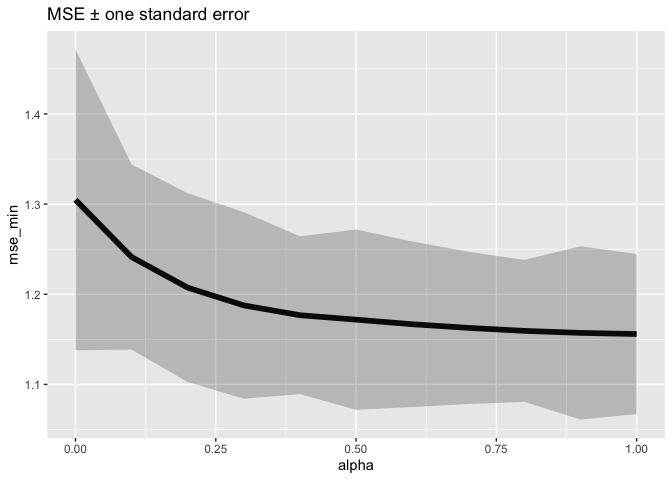

```r
tuning_grid %>%
  mutate(se = mse_1se - mse_min) %>%
  ggplot(aes(alpha, mse_min)) +
  geom_line(size = 2) +
  geom_ribbon(aes(ymax = mse_min + se, ymin = mse_min - se), alpha = .25) +
  ggtitle("MSE ± one standard error")
```

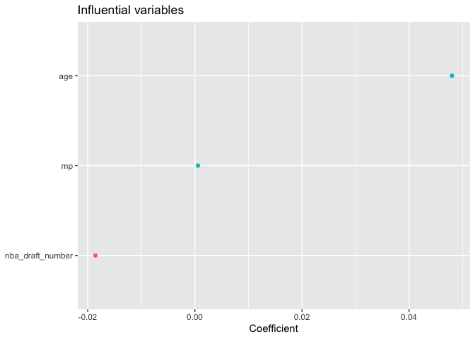

```r
coef(fit, s = "lambda.1se") %>%
  tidy() %>%
  filter(row != "(Intercept)") %>%
  ggplot(aes(value, reorder(row, value), color = value > 0)) +
  geom_point(show.legend = FALSE) +
  ggtitle("Influential variables") +
  xlab("Coefficient") +
  ylab(NULL)
```

Use the plotres() function to plot model diagnostics for glmnet models

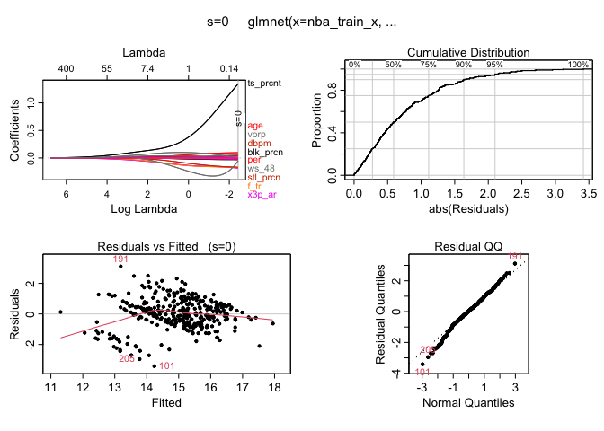

```r
# install.packages("plotmo")
#library(plotmo)
plotres(nba_ridge)
```

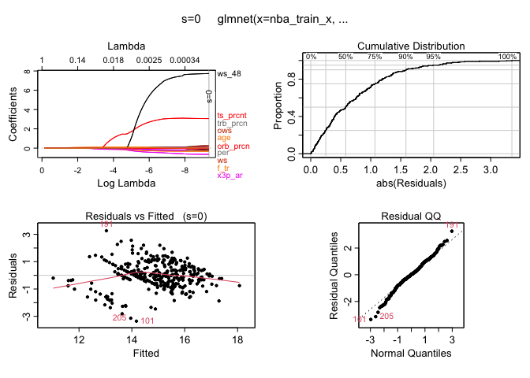

```r
plotres(nba_lasso)
```

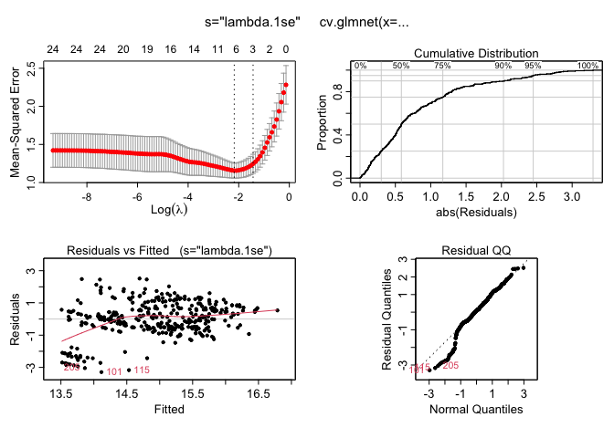

```r
plotres(fit)
```

```r
# The first plot shows the estimated slope for each parameter for # different values of (log) lambda. Notice the different shape
# between ridge and LASSO.
```

## Predicción

Vamos a comparar la prediccion de cada uno de los metodos y utilizaremos el que tiene menor mse.test.mean

```r
# some best model
cv_ridge   <- cv.glmnet(nba_train_x, nba_train_y, alpha = 0.0)
min(cv_ridge$cvm)
```

```
## [1] 1.223722
```

```r
# predict
pred <- predict(cv_ridge, s = cv_ridge$lambda.min, nba_test_x)
mean((nba_test_y - pred)^2)   # prediccion con ridge
```

```
## [1] 1.066178
```

```r
# some best model
cv_lasso   <- cv.glmnet(nba_train_x, nba_train_y, alpha = 1.0)
min(cv_lasso$cvm)
```

```
## [1] 1.145591
```

```r
# predict
pred <- predict(cv_lasso, s = cv_lasso$lambda.min, nba_test_x)
mean((nba_test_y - pred)^2)   # prediccion con lasso
```

```
## [1] 1.025789
```

```r
# some best model
cv_net   <- cv.glmnet(nba_train_x, nba_train_y, alpha = 0.2)
min(cv_net$cvm)
```

```
## [1] 1.199466
```

```r
# predict
pred <- predict(cv_net, s = cv_net$lambda.min, nba_test_x)
mean((nba_test_y - pred)^2)    #prediccion con elastic net
```

```
## [1] 1.038679
```

Vamos a elegir el modelo lasso ya que es el modelo mas simple junto con el modelo elastic net pero tiene menor mse.test.mean que elastic net. El modelo ridge lo rechazo porq no elimina variables explicativas del modelo y ademas tiene un promedio de error mayor.